# Practical Machine Learning Assessment

Pratyusa Mukherjee

October 30, 2016

## Introduction

This project predicts, using different models created by 2 different algorithms, how well participants in a study are performing certain exercises, using data from the Weight Lifting Exercise Dataset.

## Question

Can we predict how well an exercise is being performed (class A-E) using data gathered from accelerometers placed strategically using a machine learning algorithm?

## Data

The data was collected from accelerometers attached to the belt, forearm, arm, and dumbell of the participants.

### Setup Environment

The following packages are required for this code.

```r
library(AppliedPredictiveModeling)
library(caret)
library(rattle)
```

```r
library(rpart.plot)
library(randomForest)
```

#### Set the working directory, then download the files as shown

```r
url_train <- "https://d396qusza40orc.cloudfront.net/predmachlearn/pml-training.csv"
file_train <- "pml-training.csv"
download.file(url=url_train, destfile=file_train)
url_test <- "https://d396qusza40orc.cloudfront.net/predmachlearn/pml-testing.csv"
file_test <- "pml-testing.csv"
download.file(url=url_test, destfile=file_test)
```

### Prepare the Data

```r
df_train <- read.csv(file_train, na.strings=c("NA","#DIV/0!",""), header=TRUE)
cols_train <- colnames(df_train)
df_test <- read.csv(file_test, na.strings=c("NA","#DIV/0!",""), header=TRUE)
cols_test <- colnames(df_test)
```

## Feature Set

#### Verify that the column names (excluding classe and problem_id) are identical in the training and test set.

```r
all.equal(cols_train[1:length(cols_train)-1], cols_test[1:length(cols_train)-1])
```

```
## [1] TRUE
```

#### Create a function to count the number of non-NAs in each column

```r
nonNAVals <- function(x) {
  as.vector(apply(x, 2, function(x) length(which(!is.na(x)))))
}
```

#### Build a vector, of missing data or NA columns, to drop from the dataset. We don’t need them for the project.

```r
colcnts <- nonNAVals(df_train)
dropcols <- c()
for (cnt in 1:length(colcnts)) {
  if (colcnts[cnt] < nrow(df_train)) {
    dropcols <- c(dropcols, cols_train[cnt])
  }
}
```

#### Drop the NA columns as well as the first 7 columns (which are simply informative and irrelevant to what we are doing here)

```r
df_train <- df_train[,!(names(df_train) %in% dropcols)]
df_train <- df_train[,8:length(colnames(df_train))]

df_test <- df_test[,!(names(df_test) %in% dropcols)]
df_test <- df_test[,8:length(colnames(df_test))]
```

#### Print the remaining columns. These will be the features we use for prediction.

```r
colnames(df_train)
```

```
##  [1] "roll_belt"            "pitch_belt"           "yaw_belt"
##  [4] "total_accel_belt"     "gyros_belt_x"         "gyros_belt_y"
##  [7] "gyros_belt_z"         "accel_belt_x"         "accel_belt_y"
## [10] "accel_belt_z"         "magnet_belt_x"        "magnet_belt_y"
## [13] "magnet_belt_z"        "roll_arm"             "pitch_arm"
## [16] "yaw_arm"              "total_accel_arm"      "gyros_arm_x"
## [19] "gyros_arm_y"          "gyros_arm_z"          "accel_arm_x"
## [22] "accel_arm_y"          "accel_arm_z"          "magnet_arm_x"
## [25] "magnet_arm_y"         "magnet_arm_z"         "roll_dumbbell"
## [28] "pitch_dumbbell"       "yaw_dumbbell"         "total_accel_dumbbell"
## [31] "gyros_dumbbell_x"     "gyros_dumbbell_y"     "gyros_dumbbell_z"
## [34] "accel_dumbbell_x"     "accel_dumbbell_y"     "accel_dumbbell_z"
## [37] "magnet_dumbbell_x"    "magnet_dumbbell_y"    "magnet_dumbbell_z"
## [40] "roll_forearm"         "pitch_forearm"        "yaw_forearm"
## [43] "total_accel_forearm"  "gyros_forearm_x"      "gyros_forearm_y"
## [46] "gyros_forearm_z"      "accel_forearm_x"      "accel_forearm_y"
## [49] "accel_forearm_z"      "magnet_forearm_x"     "magnet_forearm_y"
## [52] "magnet_forearm_z"     "classe"
```

#### We then check the covariates with close to no variablity.

```r
nzv <- nearZeroVar(df_train, saveMetrics=TRUE)
nzv
```

From the output (supressed), we can see that all the near zero variance variables are ‘FALSE’. Therefore, we don’t need to drop any covariates.

## Algorithms

Next, we’ll try two different algorithms: classification trees and random forests.

#### Partition the training data into one set to train and another set to test

We’re going to divide the training data into two different groups: we’ll take a randomly selected 60% of the set for training, and use the remaining 40% for testing.

```r
dataToTrain <- createDataPartition(y=df_train$classe, p=0.6, list=FALSE)
df_to_train <- df_train[dataToTrain,]
df_to_test <- df_train[-dataToTrain,]
```

## Parameters

#### Cross Validation

Now we are going to perform cross validation for both the models, with K =3.

```r
fitControl <- trainControl(method='cv', number = 3)
```

## Evaluation

### Models

We will create the models using rpart and randomForests.

#### RPART

```r
model_cart <- train(
  classe ~ .,
  data=df_to_train,
  trControl=fitControl,
  method='rpart'
)

print(model_cart, digits=3)
```

```
## CART
##
## 11776 samples
##    52 predictor
##     5 classes: 'A', 'B', 'C', 'D', 'E'
##
## No pre-processing
## Resampling: Cross-Validated (3 fold)
## Summary of sample sizes: 7850, 7851, 7851
## Resampling results across tuning parameters:
##
##   cp      Accuracy  Kappa
##   0.0314  0.517     0.3700
##   0.0596  0.453     0.2707
##   0.1183  0.339     0.0836
##
## Accuracy was used to select the optimal model using  the largest value.
## The final value used for the model was cp = 0.0314.
```

As we can see, the accuracy of this model is not ideal. The following is a plot for the model.

#### RpartPlot

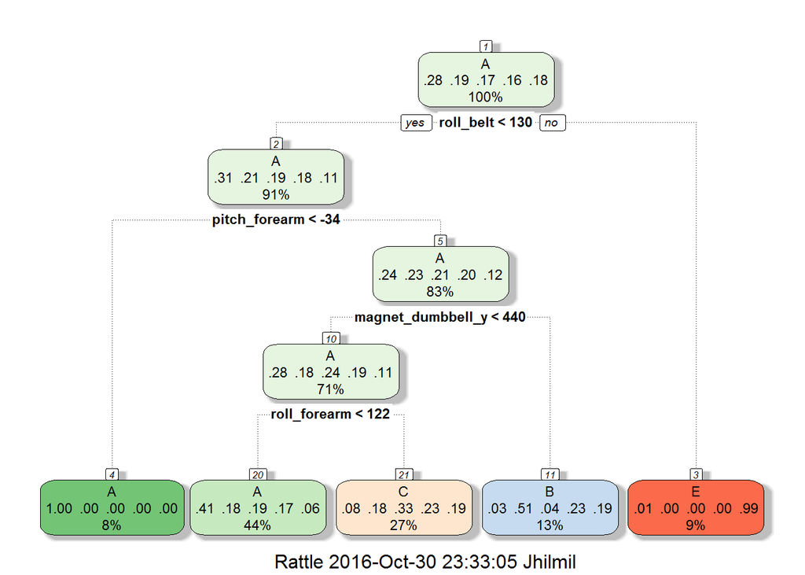

```r
fancyRpartPlot(model_cart$finalModel)
```

#### Random Forests

Now let’s try the random forest algorithm.

```r
model_rf <- train(
  classe ~ .,
  data=df_to_train,
  trControl=fitControl,
  method='rf',
  ntree=100
)

print(model_rf, digits=3)
```

```
## Random Forest
##
## 11776 samples
##    52 predictor
##     5 classes: 'A', 'B', 'C', 'D', 'E'
##
## No pre-processing
## Resampling: Cross-Validated (3 fold)
## Summary of sample sizes: 7849, 7850, 7853
## Resampling results across tuning parameters:
##
##   mtry  Accuracy  Kappa
##    2    0.983     0.979
##   27    0.987     0.983
##   52    0.977     0.971
##
## Accuracy was used to select the optimal model using  the largest value.
## The final value used for the model was mtry = 27.
```

```r
predCART <- predict(model_cart, newdata=df_to_test)
cmCART <- confusionMatrix(predCART, df_to_test$classe)
predRF <- predict(model_rf, newdata=df_to_test)
cmRF <- confusionMatrix(predRF, df_to_test$classe)
AccuracyResults <- data.frame(
  Model = c('CART', 'RF'),
  Accuracy = rbind(cmCART$overall[1], cmRF$overall[1])
)
print(AccuracyResults)
```

```
##   Model  Accuracy
## 1  CART 0.4931175
## 2    RF 0.9889115
```

As we can see, the accuracy of the RF model is very good with the test data provided.

## Conclusion

Based on the accuracy of the RF model I chose to use that model to predict for the actual test data provided.

```r
# Validation against actual test data
predValidation <- predict(model_rf, newdata=df_test)
ValidationPredictionResults <- data.frame(
  problem_id=df_test$problem_id,
  predicted=predValidation
)

#print the results for the test data
print(ValidationPredictionResults)
```

```
##    problem_id predicted
## 1           1         B
## 2           2         A
## 3           3         B
## 4           4         A
## 5           5         A
## 6           6         E
## 7           7         D
## 8           8         B
## 9           9         A
## 10         10         A
## 11         11         B
## 12         12         C
## 13         13         B
## 14         14         A
## 15         15         E
## 16         16         E
## 17         17         A
## 18         18         B
## 19         19         B
## 20         20         B
```